# FigureYa13 GSEA

小丫画图出品

6/17/2018

微信ID: epigenomics E-mail: epigenomics@rainbow-genome.com

本代码作者：Guangchuang Yu

小丫编辑校验

### 需求描述

用R代码画出paper里四个画一起的GSEA结果图

在嘉因公众号回复“GSEA”查看详情。

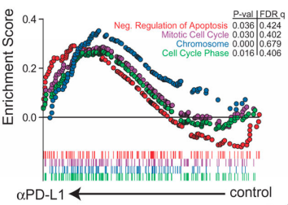

出自https://www.ncbi.nlm.nih.gov/pmc/articles/PMC5484795/

### 使用场景

在paper里用一个图的空间展示富集的多个通路的GSEA结果。

### 输入数据的预处理

如果你已经做完了GSEA，也建议你用clusterProfiler再做一次GSEA，因为：

富集分析需要不断地维护，更新知识库；不像其它软件，写好了可以用几年。富集分析的软件非常多，但多半不能用，而多半软件是不维护的，这就是问题之所在。如果你使用Broad Institute的GSEA软件，要小心了，它的KEGG注释还停留在2012年。

所以这里我们使用`clusterProfiler`，它解决了三个问题：

一是支持大量的非模式生物；

二是支持多种知识库；

三是支持在线数据。

这是大量同类软件的短板，很多只支持GO/KEGG，只支持少量模式生物，基本不更新维护，所以这里我们要使用`clusterProfiler`，而不是用别的软件的结果，直接以实验结果（全基因组表达量）做为输入，衔接`clusterProfiler`，最后出图，完事。

做GSEA，需要一个排序文件，此处输入数据是基因组上所有基因的变化倍数：`easy_input_rnk.txt`，等同于java版本GSEA的rnk文件。

参考《[听说你有RNAseq数据却不知道怎么跑GSEA](http://mp.weixin.qq.com/s/aht5fQ10nH_07CYttKFH7Q)》

```r
library(clusterProfiler)
df = read.table("easy_input_rnk.txt",header = T,as.is = T)
dim(df)
```

```
## [1] 12444     2
```

```r
head(df)
```

```
##     SYMBOL  foldChange
## 1      A2M -0.50361737
## 2     NAT1 -3.25012047
## 3     NAT2 -0.28492113
## 4 SERPINA3 -0.63137249
## 5    AADAC -0.18896102
## 6     AAMP -0.03605823
```

此处第一列是基因名，需要先转换成ENTREZID。

如果你的基因ID是其他ID，也可以用clusterProfiler转换，TCGA也用它来做转换，参考《[最靠谱的富集分析，超炫的展示方式，TCGA也是他的粉丝](https://mp.weixin.qq.com/s/Kroi9PGNbMlt2SEhqLAU1A)》

```r
df.id<-bitr(df$SYMBOL, fromType = "SYMBOL", toType = "ENTREZID",OrgDb = "org.Hs.eg.db")
head(df.id)
```

```
##     SYMBOL ENTREZID
## 1      A2M        2
## 2     NAT1        9
## 3     NAT2       10
## 4 SERPINA3       12
## 5    AADAC       13
## 6     AAMP       14
```

```r
dim(df.id)
```

```
## [1] 12446     2
```

```r
#让基因名、ENTREZID、foldchange对应起来
easy.df<-merge(df,df.id,by="SYMBOL",all=F)
#按照foldchange排序
sortdf<-easy.df[order(easy.df$foldChange, decreasing = T),]
head(sortdf)
```

```
##      SYMBOL foldChange ENTREZID
## 6508   MMP1   4.572613     4312
## 1743  CDC45   4.514594     8318
## 7159    NMU   4.418218    10874
## 1750  CDCA8   4.144075    55143
## 6295  MCM10   3.876258    55388
## 1725  CDC20   3.677857      991
```

```r
gene.expr = sortdf$foldChange
names(gene.expr) <- sortdf$ENTREZID
head(gene.expr)
```

```
##     4312     8318    10874    55143    55388      991
## 4.572613 4.514594 4.418218 4.144075 3.876258 3.677857
```

有了这个ENTREZID和foldchange信息的`gene.expr`之后，就可以使用`clusterProfiler`进行GSEA分析了。

### 进行GSEA分析

```r
require(enrichplot)
require(clusterProfiler)
kk <- gseKEGG(gene.expr, organism = "hsa")
```

这一条语句就做完了KEGG的GSEA分析。

另外，还可以用GO、MSigDB、以及自定义的gene set做富集分析。

### GSEA结果保存

按照enrichment score从高到低排序，便于查看富集通路

```r
sortkk<-kk[order(kk$enrichmentScore, decreasing = T),]
write.table(sortkk,"gsea_output.txt",sep = "\t",quote = F,col.names = T,row.names = F)
```

通过查看gsea_output.txt,选择你想画的pathway，记下通路的term ID。

### 开始画图

不需要另外准备输入文件，`clusterProfiler`直接可以用`gseaplot`出图：

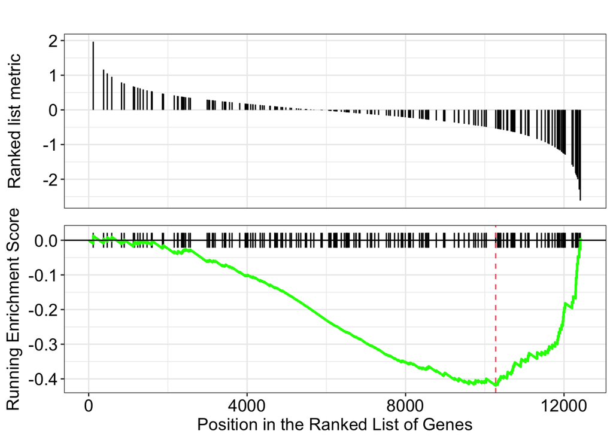

```r
gseaplot(kk, "hsa04510")
```

当然你可以改线条颜色：

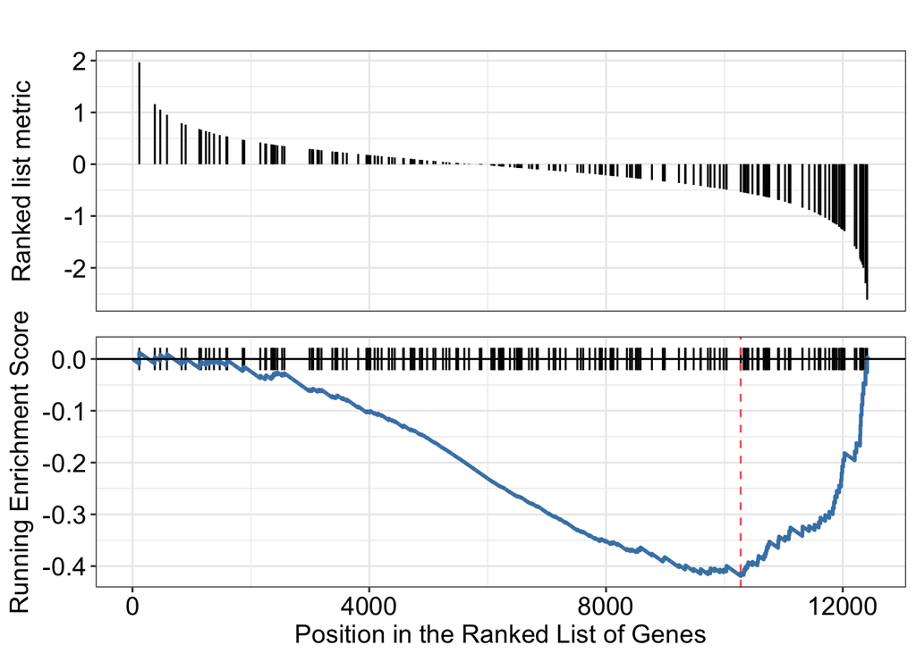

```r
gseaplot(kk, "hsa04510", color.line='steelblue')
```

另一种出图方式是模拟Broad institute的GSEA软件的图，可以用`gseaplot2`出图：

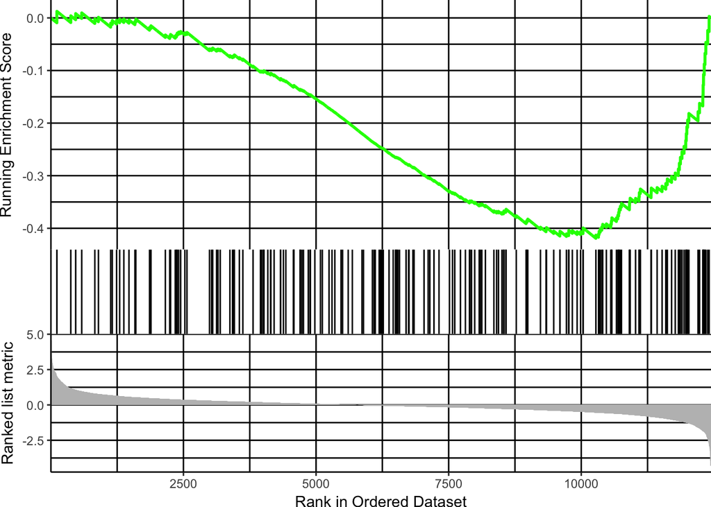

```r
gseaplot2(kk, "hsa04510")
```

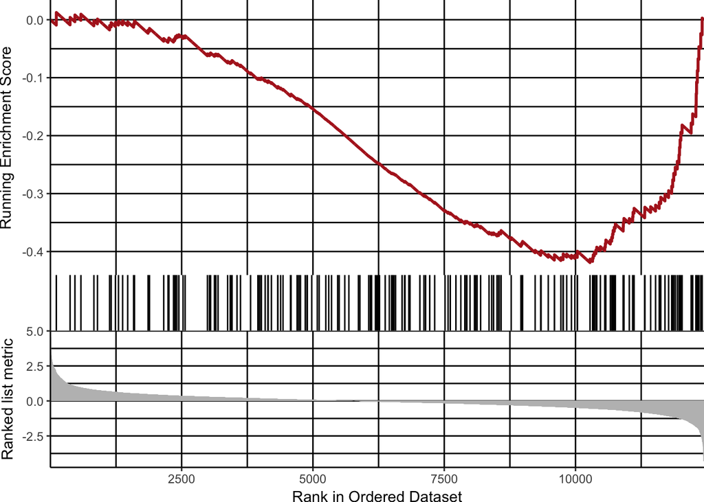

```r
gseaplot2(kk, "hsa04510", color = "firebrick", rel_heights=c(1, .2, .6))
```

它还有更外一个功能，就是支持同时展示多个pathways的结果

需要开发版本的`enrichplot`软件，请通过以下指令安装：

```r
devtools::install_github("GuangchuangYu/enrichplot")
```

画出enrichment score排名前4的pathway

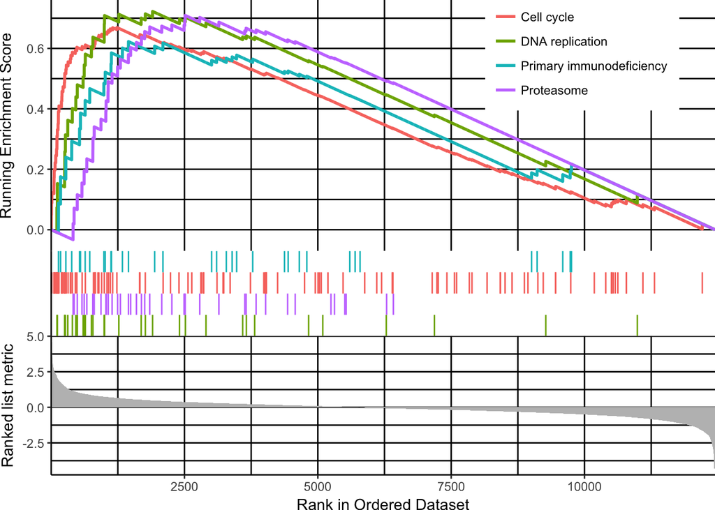

```r
gseaplot2(kk, row.names(sortkk)[1:4])
```

也可以通过查看gsea_output.txt，挑出你想show的pathway，给它以hsa开头的KEGG ID

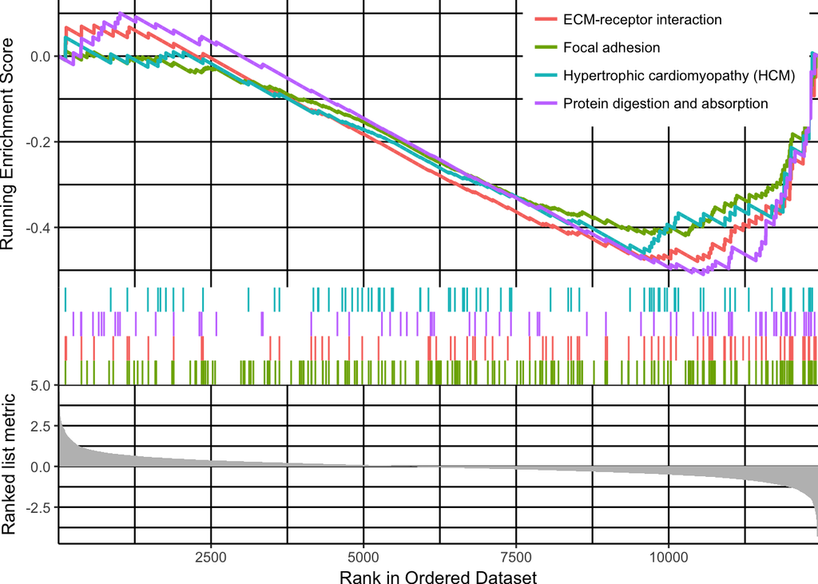

```r
paths <- c("hsa04510", "hsa04512", "hsa04974", "hsa05410")
gseaplot2(kk, paths)
```

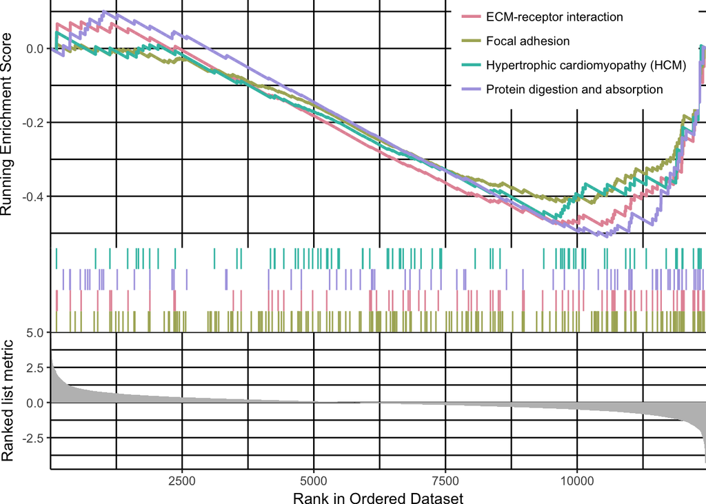

```r
gseaplot2(kk, paths, color = colorspace::rainbow_hcl(4))
```

如果你不想同时展示3个subplots，而只想选取其中某一些，也是可以的，通过`subplots`参数：

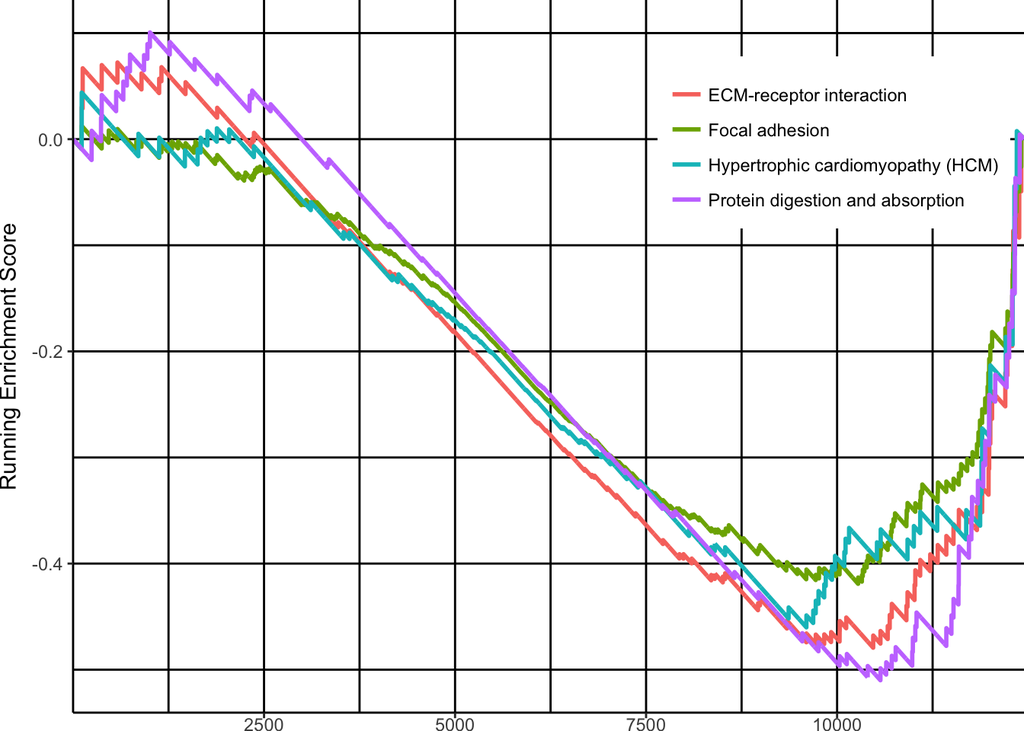

```r
gseaplot2(kk, paths, subplots=1)
```

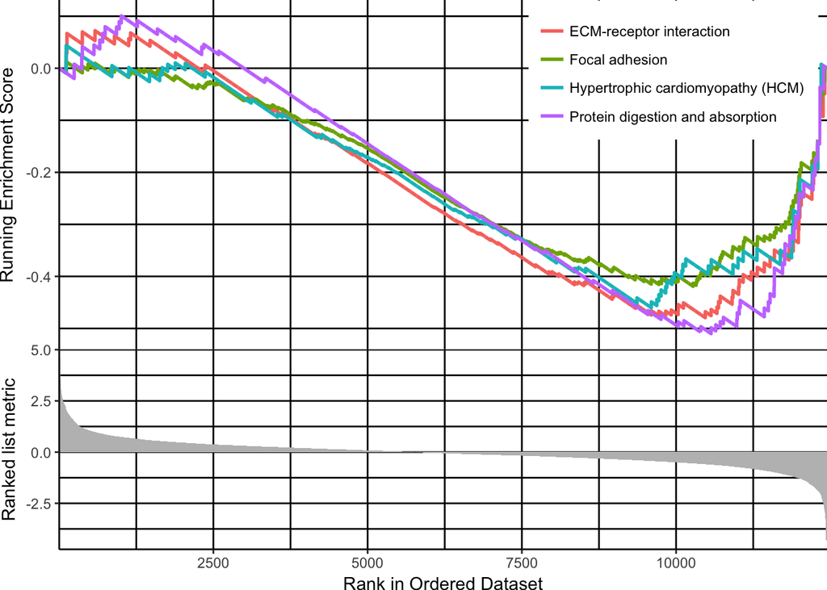

```r
#gseaplot2(kk, paths, subplots=1:2)
gseaplot2(kk, paths, subplots=c(1,3))
```

当然还可以直接把pvalue table注释在图片上

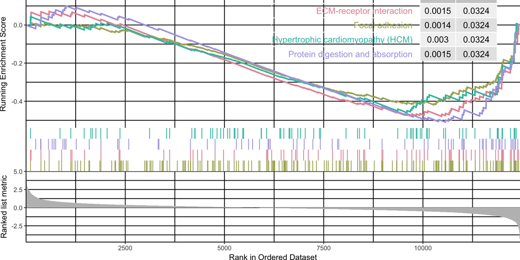

```r
gseaplot2(kk, paths, color = colorspace::rainbow_hcl(4), pvalue_table = TRUE)
```

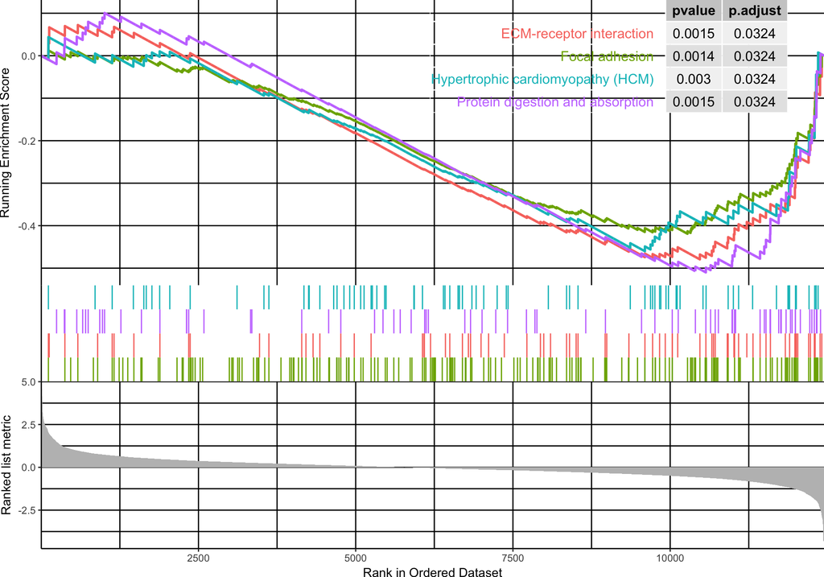

```r
gseaplot2(kk, paths, pvalue_table = TRUE)
```

`enrichplot`提供了多种可视化方式，不单单是上面展示的这些，请移步在线文档http://bioconductor.org/packages/devel/bioc/vignettes/enrichplot/inst/doc/enrichplot.html，想要及时了解新功能，请关注公众号[biobabble](https://guangchuangyu.github.io/blog_images/biobabble.jpg) 。